# Predicting Exercise

Carl McKinney

7/16/2018

### Introduction

The goal of this project is to predict manner of exercise based on data from accelerometers on the belt, forearm, arm, and dumbell of 6 participants who were asked to perform barbell lifts correctly and incorrectly in 5 different ways. More information is available here: http://web.archive.org/web/20161224072740/http:/groupware.les.inf.puc-rio.br/har (see the section on the Weight Lifting Exercise Dataset).

```r
## Load necessary libraries
library(caret)
library(randomForest)
library(rpart)
library(rpart.plot)
library(ggplot2)

## Load data sets
trainUrl<-"https://d396qusza40orc.cloudfront.net/predmachlearn/pml-training.csv"
testUrl<-"https://d396qusza40orc.cloudfront.net/predmachlearn/pml-testing.csv"
train<-read.csv(trainUrl,na.strings=c("NA","","#DIV0!"))
test<-read.csv(testUrl,na.strings=c("NA","","#DIV0!"))

## Clean data - remove columns with no data or unnecessary for prediction model, e.g. user name, timestamps, etc
train<-train[,colSums(is.na(train))==0]
test<-test[,colSums(is.na(test))==0]
train<-train[,8:dim(train)[2]]
test<-test[,8:dim(test)[2]]
```

### Cross Validation

Cross validation will be conducted by splitting the training data set into training and testing sets.

```r
set.seed(6269)
inTrain<-createDataPartition(train$classe,p=0.7,list=FALSE)
trainCV<-train[inTrain,]
testCV<-train[-inTrain,]
```

### Exploratory Analysis

We will attempt to predict the ‘classe’ variable, which is an unordered factor variable with 5 levels indicating how participants performed a set of 10 repetitions of the Unilateral Dumbell Biceps Curl:

- Class A: exactly according to the specification
- Class B: throwing the elbows to the front
- Class C: lifting the dumbbell only halfway
- Class D: lowering the dumbbell only halfway
- Class E: throwing the hips to the front

Scatter plots of some of the acceleration data from the training cross-validation set reveal a lot of similarity between classes of performance:

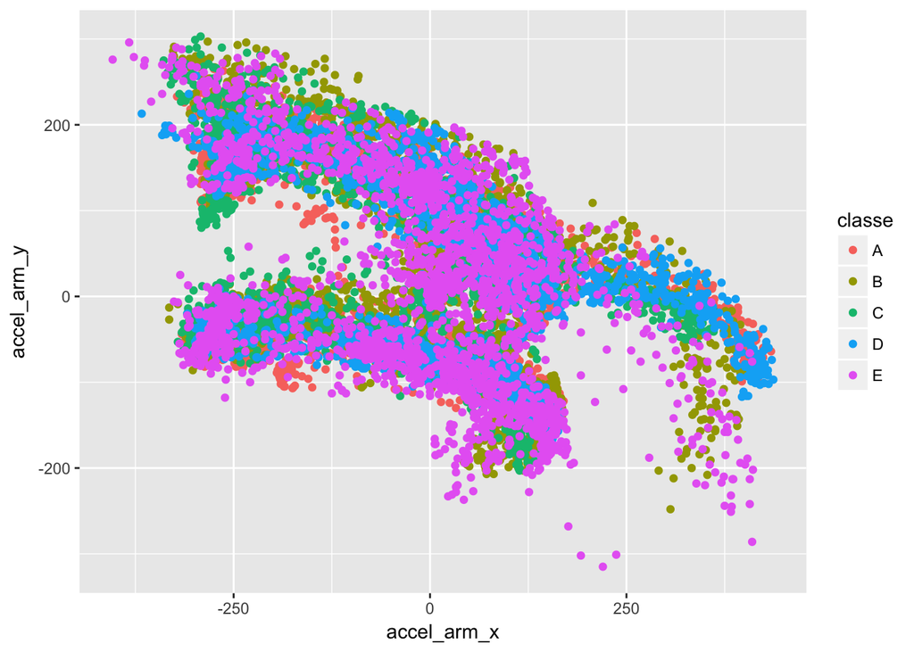

```r
qplot(accel_arm_x,accel_arm_y,col=classe,data=trainCV)
```

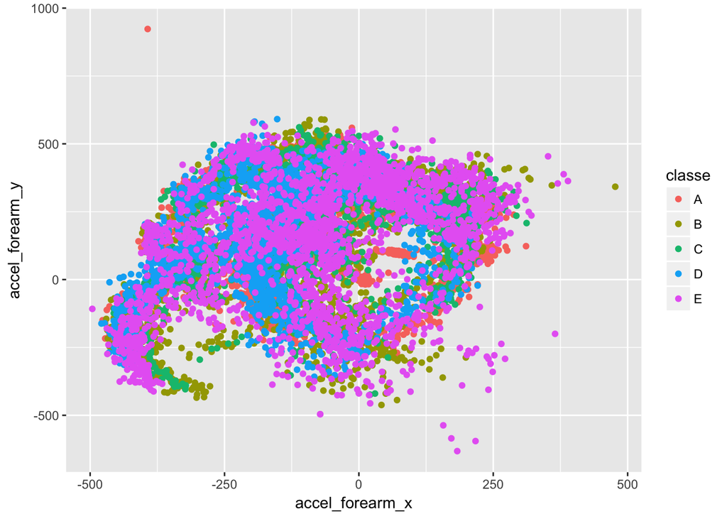

```r
qplot(accel_forearm_x,accel_forearm_y,col=classe,data=trainCV)
```

### Prediction Models

We will use all variable not already cleaned from the data set and try both tree and random forests methods for modeling, and then evaluate the models based on accuracy and out-of-sample error.

```r
## Create model and run prediction
tree<-rpart(classe~.,data=trainCV,method="class")
predictTree<-predict(tree,testCV,type="class")
Ctree<-confusionMatrix(predictTree,testCV$classe)
Ctree
```

```
## Confusion Matrix and Statistics
##
##           Reference
## Prediction    A    B    C    D    E
##          A 1525  235   22  112   30
##          B   49  580   52   33   58
##          C   35  217  871  103  126
##          D   32   79   81  636   64
##          E   33   28    0   80  804
##
## Overall Statistics
##
##                Accuracy : 0.7504
##                  95% CI : (0.7391, 0.7614)
##     No Information Rate : 0.2845
##     P-Value [Acc > NIR] : < 2.2e-16
##
##                   Kappa : 0.6829
##  Mcnemar's Test P-Value : < 2.2e-16
##
## Statistics by Class:
##
##                      Class: A Class: B Class: C Class: D Class: E
## Sensitivity            0.9110  0.50922   0.8489   0.6598   0.7431
## Specificity            0.9052  0.95954   0.9010   0.9480   0.9706
## Pos Pred Value         0.7926  0.75130   0.6442   0.7130   0.8508
## Neg Pred Value         0.9624  0.89067   0.9658   0.9343   0.9437
## Prevalence             0.2845  0.19354   0.1743   0.1638   0.1839
## Detection Rate         0.2591  0.09856   0.1480   0.1081   0.1366
## Detection Prevalence   0.3269  0.13118   0.2297   0.1516   0.1606
## Balanced Accuracy      0.9081  0.73438   0.8750   0.8039   0.8569
```

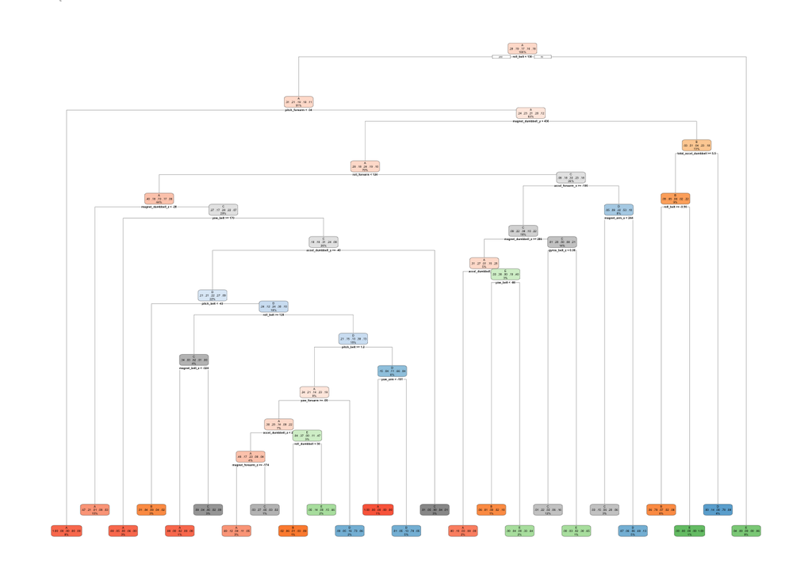

```r
## Plot prediction tree
rpart.plot(tree)
```

The tree diagram is a little hard to see, but in the statistical output we can see that this method is only about 75% accurate at predicting the manner of exercise when applied to the test set.

```r
## Create model and run prediction
RF<-randomForest(classe~.,data=trainCV,method="class")
predictRF<-predict(RF,testCV,type="class")
CRF<-confusionMatrix(predictRF,testCV$classe)
CRF
```

```
## Confusion Matrix and Statistics
##
##           Reference
## Prediction    A    B    C    D    E
##          A 1670    8    0    0    0
##          B    4 1130   12    0    0
##          C    0    1 1014   12    1
##          D    0    0    0  951    2
##          E    0    0    0    1 1079
##
## Overall Statistics
##
##                Accuracy : 0.993
##                  95% CI : (0.9906, 0.995)
##     No Information Rate : 0.2845
##     P-Value [Acc > NIR] : < 2.2e-16
##
##                   Kappa : 0.9912
##  Mcnemar's Test P-Value : NA
##
## Statistics by Class:
##
##                      Class: A Class: B Class: C Class: D Class: E
## Sensitivity            0.9976   0.9921   0.9883   0.9865   0.9972
## Specificity            0.9981   0.9966   0.9971   0.9996   0.9998
## Pos Pred Value         0.9952   0.9860   0.9864   0.9979   0.9991
## Neg Pred Value         0.9990   0.9981   0.9975   0.9974   0.9994
## Prevalence             0.2845   0.1935   0.1743   0.1638   0.1839
## Detection Rate         0.2838   0.1920   0.1723   0.1616   0.1833
## Detection Prevalence   0.2851   0.1947   0.1747   0.1619   0.1835
## Balanced Accuracy      0.9979   0.9944   0.9927   0.9931   0.9985
```

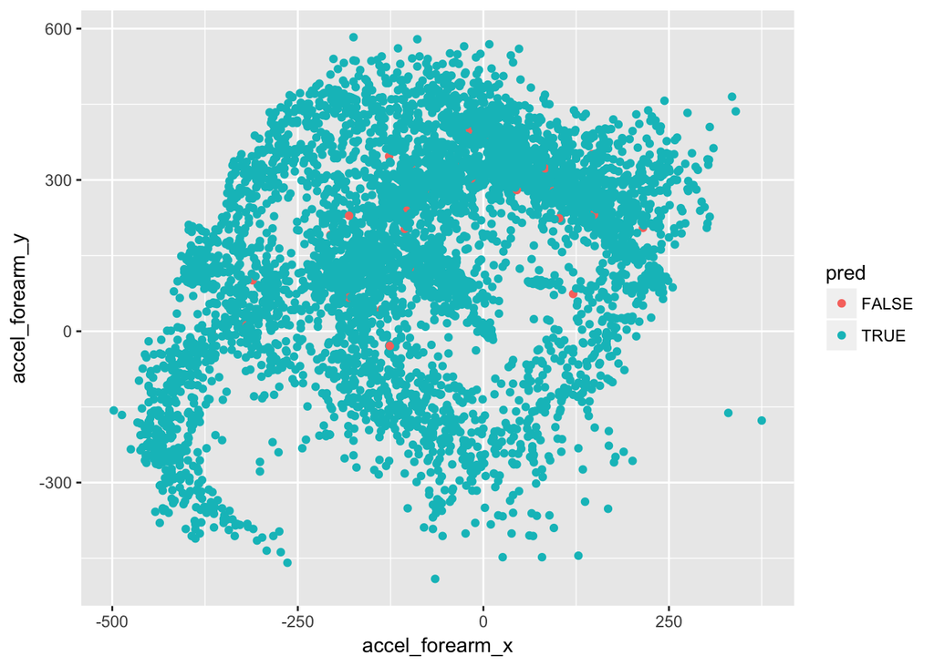

```r
## Plot predictions against test data
CV<-testCV
CV$pred<-testCV$classe==predictRF
qplot(accel_forearm_x,accel_forearm_y,col=pred,data=CV)
```

We can see both in the plot and the statistical output that the random forest method is much better at predicting manner of exercise when applied to the test set, with about 99% accuracy.

### Conclusion

The table below compares the accuracy and out-of-sample error for the tree and random forest models:

| Model | Accuracy | Out-of-Sample Error |
| --- | --- | --- |
| Tree | 0.7503823 | 0.2496177 |
| Random Forest | 0.9930331 | 0.0069669 |

Clearly the random forest is a much better model for predicting manner of exercise in this dataset. Below is the prediction for the test set:

```r
prediction<-predict(RF,test)
prediction
```

```
##  1  2  3  4  5  6  7  8  9 10 11 12 13 14 15 16 17 18 19 20
##  B  A  B  A  A  E  D  B  A  A  B  C  B  A  E  E  A  B  B  B
## Levels: A B C D E
```